# Prediction Assignment Writeup

Andre Luna

December 12, 2018

```r
#Reading data
training <- read.table("C://Users//Consultor//Desktop//course_project//pml-training.csv", sep = ",", header = T, na.strings = c("", "NA", "#DIV/0!"))
testing <- read.table("C://Users//Consultor//Desktop//course_project//pml-testing.csv", sep = ",", header = T, na.strings = c("", "NA", "#DIV/0!"))
```

## Executive Summary

Using data from accelerometers on the belt, forearm, arm, and dumbell of 6 participants the study captured several dimensions of a barbell lift exercise, conducted both correctly and incorrectly in 5 different ways. Base on the gathered data, this study proposed to predict if a given exercise was conducted correcly or not, classifying it in the 5 ways. As the features were highly correlated, the data was processed using a PCA analysis. Two models were trained and validated - a Random Forest and a Support Vector Machine, both yielding excellent results on predicting the correct outcome.

The original study and data can be found [here](http://groupware.les.inf.puc-rio.br/har).

## Pre-processing and Exploring Data

```r
#Libraries
library(tidyverse)
library(caret)


#splitting training data into train and validation
partition <- createDataPartition(training$classe, p=0.7, list=FALSE)
training <- training[partition, ]
validation <- training[-partition, ]

#Examining data
dim(training)
dim(validation)
dim(testing)
```

```
## [1] 13737   160
## [1] 4117  160
## [1]  20 160
```

With the partioned data, it is necessary to examine the presence and structure of missing data before conducting any further transformation or analysis

### Analysing Missing Data

```r
  #function to identify missings
pMiss <- function(x){sum(is.na(x))/length(x)*100}

apply(training, 2, pMiss) #detecting proportion of missings in columns
```

[output not shown]

```r
#Removing missing-filled columns
train_clean <- training[, -which(colMeans(is.na(training)) > 0.5)]
validate_clean <- validation[, -which(colMeans(is.na(validation)) > 0.5)]
test_clean <- testing[, -which(colMeans(is.na(testing)) > 0.5)]

dim(train_clean)
dim(validate_clean)
dim(test_clean)
```

```
## [1] 13737    60
## [1] 4117   60
## [1] 20 60
```

Once the missing data are delt with, it is necessary to explore the correlation between features, as multicolinearity of variables might introduce bias to the models

### Correlation Analysis

It is first necessary to collect only the numeric variables in the data to comput the correlation matrix. In order to help visualization, we will investigate only the variables with correlation above 0.7.

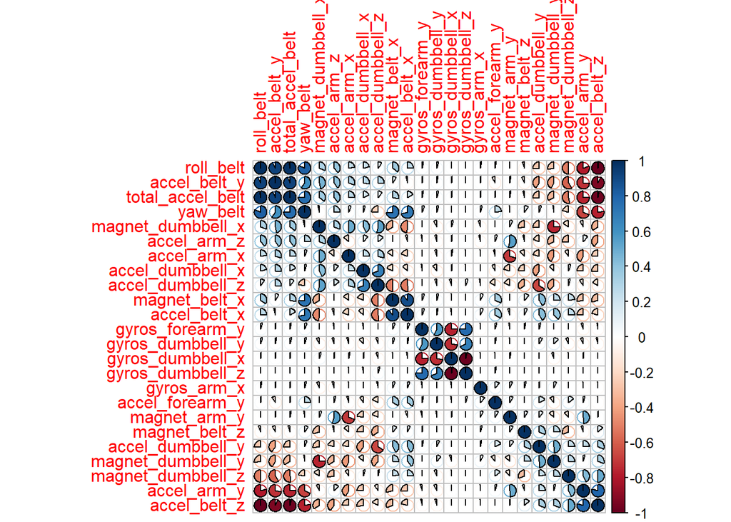

```r
#Selecting numeric variables
train_num <- dplyr::select_if(train_clean[,-1], is.numeric)
#removing index variable X
  # calculate correlation matrix
  correlationMatrix <- cor(train_num, use = "complete.obs")

  # find attributes that are highly corrected (>0.7)
  highlyCorrelated <- findCorrelation(correlationMatrix, cutoff=0.7)
  # print indexes of highly correlated attributes
  investigate_corr <- cor(train_num[, highlyCorrelated])

  #Plotting correlation matrix
library(corrplot)
corrplot(investigate_corr, method = "pie", order = "FPC")
```

It is not unexpected to see that a great number of variables is correlated with each other, especially the ones that capture different axis of the same movement. If they were in lesser numbers, an alternative would be to not include them in the model. As they are numerous, a better approach is to conduct a PCA analysis, extracting the most relevant part of the information. This action will sacrifice explanatory power of the model, which is no problem as the focus is on predicting correctly the exercise.

### PCA Analysis

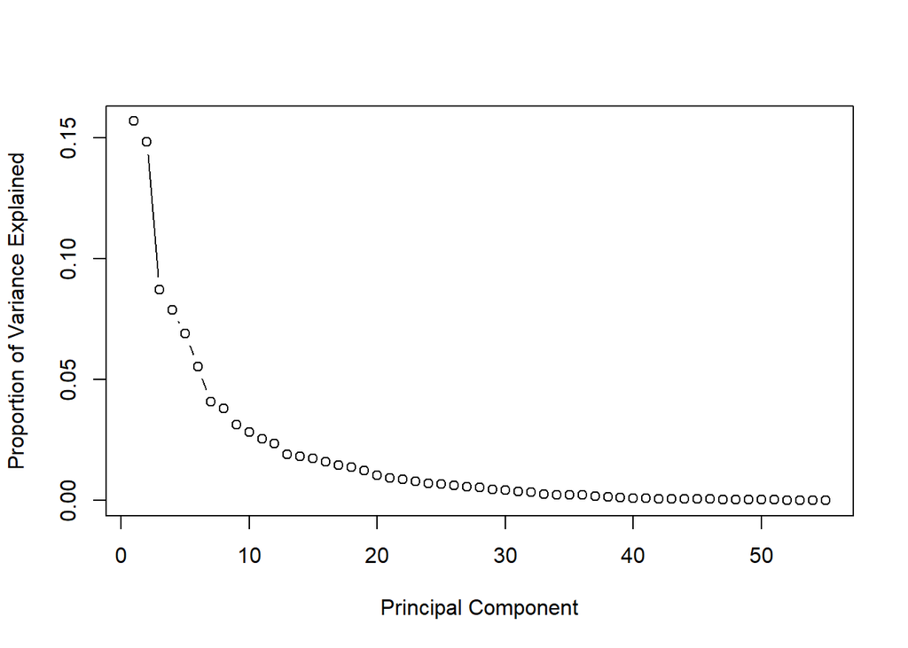

```r
pca_train <- prcomp(train_num, center = T, scale. = T)

#compute standard deviation of each principal component
 std_dev <- pca_train$sdev

#compute variance
 pr_var <- std_dev^2

 prop_varex <- pr_var/sum(pr_var)

#scree plot
 plot(prop_varex, xlab = "Principal Component",
       ylab = "Proportion of Variance Explained",
       type = "b")
```

```r
 sum(prop_varex[1:30])
```

```
## [1] 0.9709662
```

## Modelling

### Model Prep

As we are dealing with PCA vectors, it is necessary to generate similar vectors on validating and testing data with te same specifications as generated in the train data.

```r
#Capturing 30 PC vectors and the response variable
final_train <- data.frame(classe = train_clean$classe, pca_train$x[,1:30])

#Generating PCA on validation and test data
validate_num <- dplyr::select_if(validate_clean[,-1], is.numeric)
final_validate <- predict(pca_train, newdata = validate_num)
final_validate <- as.data.frame(final_validate[, 1:30])

test_num <- dplyr::select_if(test_clean[,-c(1, 60)], is.numeric)
final_test <- predict(pca_train, newdata = test_num)
final_test <- as.data.frame(final_test[, 1:30])
```

```r
 control <- trainControl(method="repeatedcv", number=5, repeats=3, search="random")
```